# Reproducible Research Project-1

Raji

April 13, 2016

### Loading and Preprocessing the Data to create tidy data set

```r
library(lattice)

setwd("C:/Raji Data/Coursera DataScience/Reproducible Research/Week1/Project1/activity")

# Load the raw activity data
activity_raw <- read.csv("activity.csv", stringsAsFactors=FALSE)

# Show few rows from raw data
head(activity_raw)
```

```
##   steps       date interval
## 1    NA 2012-10-01        0
## 2    NA 2012-10-01        5
## 3    NA 2012-10-01       10
## 4    NA 2012-10-01       15
## 5    NA 2012-10-01       20
## 6    NA 2012-10-01       25
```

### Transform the data into a format suitable for analysis

```r
# Transform the date attribute to an actual date format
activity_raw$date <- as.POSIXct(activity_raw$date, format="%Y-%m-%d")

# Get name of the  weekday from the date attribute using weekdays function and add to the raw data
activity_raw <- data.frame(date=activity_raw$date,
                           weekday=tolower(weekdays(activity_raw$date)),
                           steps=activity_raw$steps,
                           interval=activity_raw$interval)

# Compute the day type (weekend or weekday) and add this column to raw data
activity_raw <- cbind(activity_raw,
                      daytype=ifelse(activity_raw$weekday == "saturday" |
                                       activity_raw$weekday == "sunday", "weekend",
                                     "weekday"))

# Create the final data.frame - the tidy data set
tidy_activity <- data.frame(date=activity_raw$date,
                       weekday=activity_raw$weekday,
                       daytype=activity_raw$daytype,
                       interval=activity_raw$interval,
                       steps=activity_raw$steps)


head(tidy_activity)
```

```
##         date weekday daytype interval steps
## 1 2012-10-01  monday weekday        0    NA
## 2 2012-10-01  monday weekday        5    NA
## 3 2012-10-01  monday weekday       10    NA
## 4 2012-10-01  monday weekday       15    NA
## 5 2012-10-01  monday weekday       20    NA
## 6 2012-10-01  monday weekday       25    NA
```

### What is the mean total number of steps taken per day?

For this part of the assignment, the missing values in the dataset are ignored. Make a histogram of the total number of steps taken each day. Compute the total number of steps each day with NA values removed

```r
totalsteps_by_date <- aggregate(tidy_activity$steps, by=list(tidy_activity$date), FUN=sum, na.rm=TRUE)

## Rename the attributes
names(totalsteps_by_date) <- c("Date", "Total_Steps")

## Show few rows  from totalsteps_by_data
  head(totalsteps_by_date)
```

```
##         Date Total_Steps
## 1 2012-10-01           0
## 2 2012-10-02         126
## 3 2012-10-03       11352
## 4 2012-10-04       12116
## 5 2012-10-05       13294
## 6 2012-10-06       15420
```

### Histogram of Total Number of Steps For Each day:

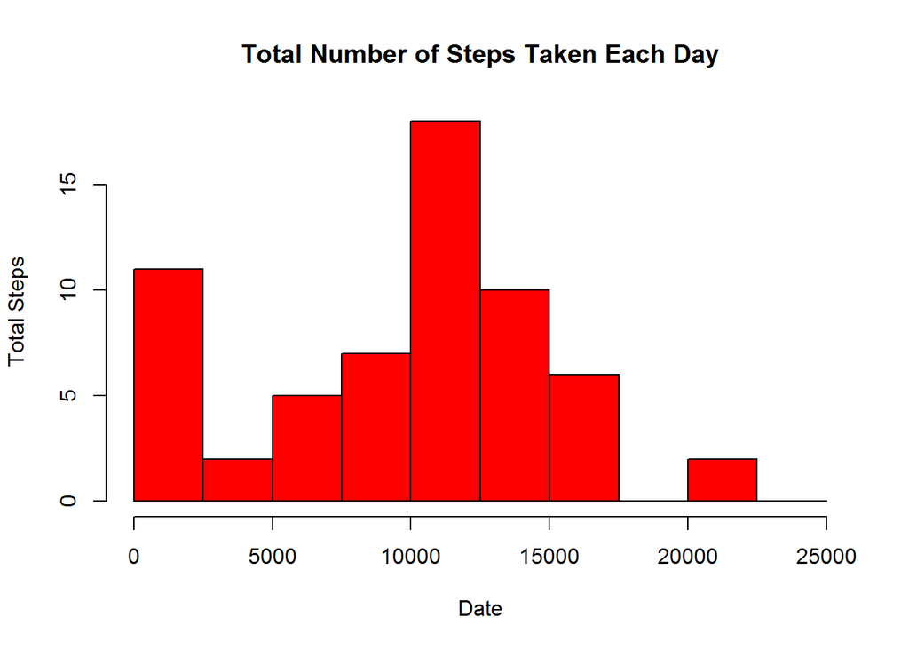

### Calculate and report the mean and median total number of steps taken per day

The mean and median are calculated as below

```r
  print(mean(totalsteps_by_date$Total_Steps))
```

```
## [1] 9354.23
```

```r
  print(median(totalsteps_by_date$Total_Steps))
```

```
## [1] 10395
```

### What is the Average Daily Activity Pattern?

```r
avg_daily_activity <- aggregate(tidy_activity$steps,
                         by=list(tidy_activity$interval),
                         FUN=mean,
                         na.rm=TRUE)

names(avg_daily_activity) <- c("interval", "average")
```

### Time Series Plot to Show Average Daily Activity

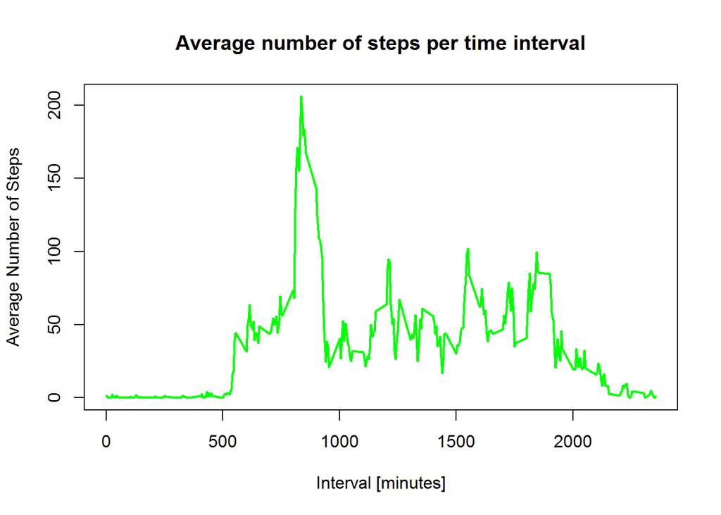

### Which 5-minute interval, on average across all the days in the dataset, contains the maximum number of steps?

```r
# Find the position of the maximum mean
max_pos <- which(avg_daily_activity$average == max(avg_daily_activity$average ))

# We lookup the value of interval at this position
max_interval <- avg_daily_activity[max_pos, 1]
print(max_interval)  ## 835
```

```
## [1] 835
```

### Imputing missing values

```r
#Calculate and report the total number of missing values in the dataset (i.e. the total number of rows with NAs)

print(NA_count <- sum(is.na(tidy_activity$steps)))  ## 2304
```

```
## [1] 2304
```

```r
#Create a new dataset that is equal to the original dataset but with the missing data filled in with the mean of steps
new_dataset <- tidy_activity

new_dataset[is.na(tidy_activity$steps), ]$steps <- mean(activity_raw$steps, na.rm = TRUE)
print(head(new_dataset))
```

```
##         date weekday daytype interval   steps
## 1 2012-10-01  monday weekday        0 37.3826
## 2 2012-10-01  monday weekday        5 37.3826
## 3 2012-10-01  monday weekday       10 37.3826
## 4 2012-10-01  monday weekday       15 37.3826
## 5 2012-10-01  monday weekday       20 37.3826
## 6 2012-10-01  monday weekday       25 37.3826
```

### Compute Total number of steps taken each day after NA substitution

```r
avg_data_after_NA_substitution <- aggregate(new_dataset$steps, by=list(new_dataset$date), FUN=sum)

# Rename the attributes
names(avg_data_after_NA_substitution) <- c("date", "total")
```